# MODELOS LINEARES GENERALIZADOS (EST082)

LISTA 3 - Modelo Binomial

Autor

Jaqueline Lamas da Silva

# 8.

**Código**

```r
suppressMessages(sementes <- read_table("dados/lista3/sementes.txt",
    col_names = FALSE))
colnames(sementes)<-c("tempGerm","umidade","temp","numGerminaram")
sementes$tempGerm<-as.factor(sementes$tempGerm)
sementes$umidade<-as.factor(sementes$umidade)
sementes$temp<-as.factor(sementes$temp)
```

## Análise Exploratória

**Código**

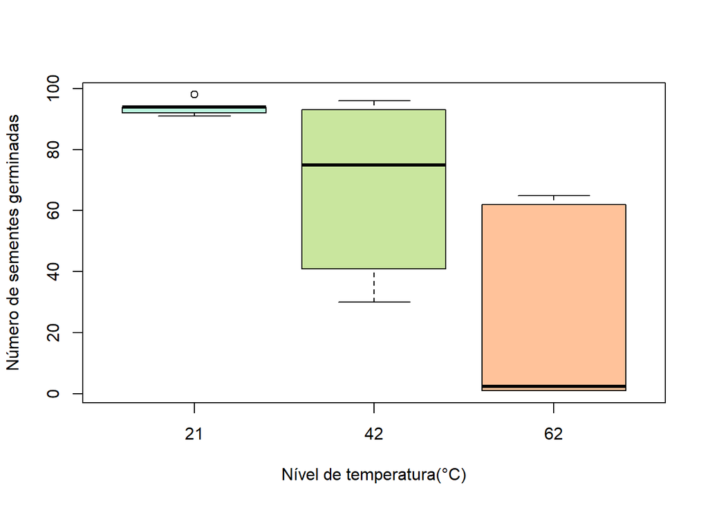

```r
suppressMessages(attach(sementes))

boxplot(numGerminaram~temp, col=cores, xlab="Nível de temperatura(°C)", ylab=c("Número de sementes germinadas"))
```

**Código**

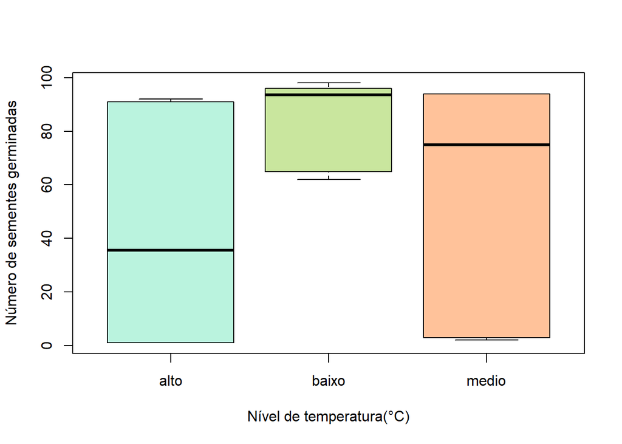

```r
boxplot(numGerminaram~umidade, col=cores, xlab="Nível de temperatura(°C)", ylab=c("Número de sementes germinadas"))
```

## Seleção do modelo

**Código**

```
[1] "Binomial-Link(logit)"
```

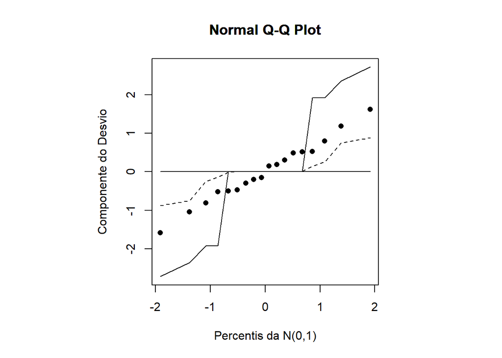

```
[1] "Binomial-Link(cauchit)"
```

```
[1] "Binomial-Link(log)"
[1] "Binomial-Link(probit)"
```

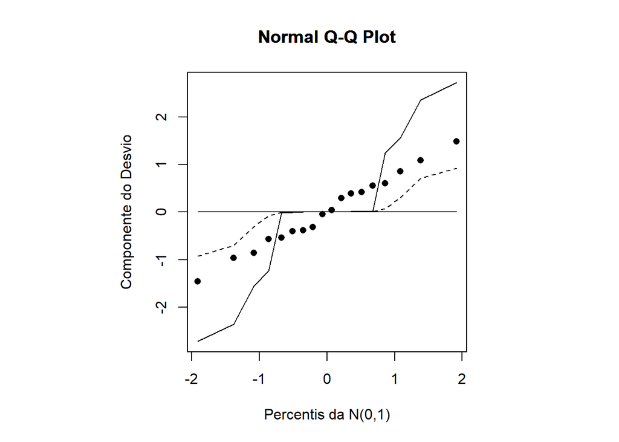

```
[1] "Binomial-Link(cloglog)"
```

```r
n<-nrow(sementes)
numFrac<-100-numGerminaram


modelo<-cbind(numGerminaram, numFrac) ~ temp + umidade + tempGerm + umidade:temp + tempGerm:umidade + temp:tempGerm
binom<-rbind(
ResultadosBinom(sementes, modelo, ligacao = "logit", tipo ="envel_bino_logit"),
ResultadosBinom(sementes, modelo, ligacao = "cauchit", tipo ="envel_bino_cauchit"),
ResultadosBinom(sementes, modelo, ligacao = "log", tipo ="envel_bino_log"),
ResultadosBinom(sementes, modelo, ligacao = "probit", tipo ="envel_bino_probit"),
ResultadosBinom(sementes, modelo, ligacao = "cloglog", tipo ="envel_bino_cloglog")
)
```

**Código**

```r
binom |>
  arrange(BIC) |>
  knitr::kable(caption = "Melhor modelo", format ="pipe")
```

Melhor modelo

| Family | QQplot | BIC | Modelo |
| --- | --- | --- | --- |
| Binomial-Link(probit) | Ruim | 100.2435 | cbind(numGerminaram, numFrac) ~ temp + umidade + tempGerm + temp:umidade |
| Binomial-Link(cloglog) | Não Rodou | 100.4024 | cbind(numGerminaram, numFrac) ~ temp + umidade + tempGerm + temp:umidade |
| Binomial-Link(logit) | Ruim | 100.4361 | cbind(numGerminaram, numFrac) ~ temp + umidade + tempGerm + temp:umidade |
| Binomial-Link(cauchit) | Não Rodou | 101.8799 | cbind(numGerminaram, numFrac) ~ temp + umidade + tempGerm + temp:umidade |
| Binomial-Link(log) | Não Rodou | NA | —– |

Nem o stepAIC nem o stepJAQ rodaram para a ligação log, pois a função glm não roda com a fórmula: cbind(numGerminaram, numFrac) ~ temp + umidade.

O modelo selecionado foi o Binomial-Link(logit) por ser mais interpretável, não tem muita diferença no BIC dele para o de melhor BIC.

NÚMERO DE SEMENTES QUE GERMINARAM ~ TEMP + UMIDADE + TEMPGERM + TEMP:UMIDADE

## Teste de adequação da função de ligação

**Código**

```r
modelo<-cbind(numGerminaram, numFrac) ~ temp + umidade + tempGerm + temp:umidade
fit.model <- glm(modelo  , family=binomial(link=logit))
pl2 <- predict(fit.model)^2
fit.model2<-glm(update.formula(modelo,~ . + pl2), family=binomial(link=logit))
testef(fit.model,fit.model2) # fit.model(H0: pl2 não significativa) #H1: pl2 é significativa
```

```
$f
[1] 0.01517107

$df1
[1] 1

$df2
[1] 7

$pvalue
[1] 0.9054337
```

Não temos evidências para rejeitar $H_0$, a função de ligação “logit” é adequada para o modelo.

## Resíduos e Diagnóstico

**Código**

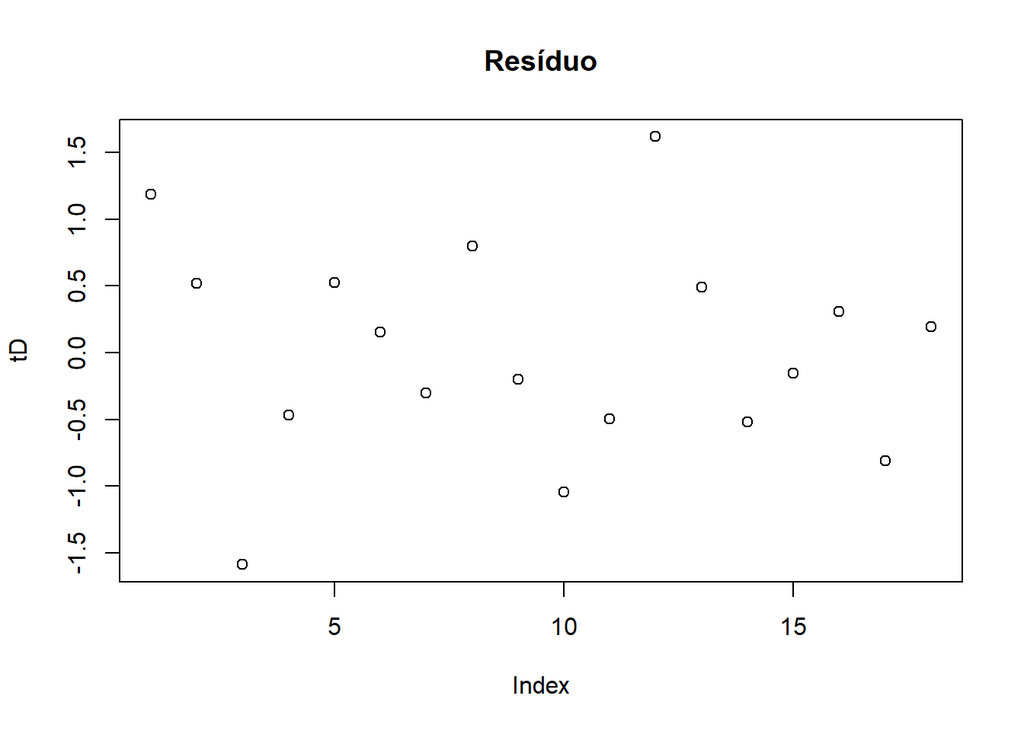

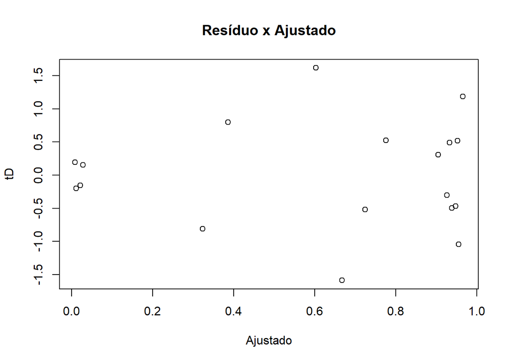

```r
modelo<-cbind(numGerminaram, numFrac) ~ temp + umidade + tempGerm + temp:umidade
fit.model <- glm(modelo  , family=binomial(link=logit))

resul.resd<-residuos(fit.model)
```

O modelo não foi validado, observa-se um padrão de funil no gráfico dos valores preditos pelo resíduo. O presusposto de homocedasticidade não foi atendido.